Chapter 3 - Bayesian Networks in the

Presence of Temporal

Information

[figure not shown]

First episode about time varying effects

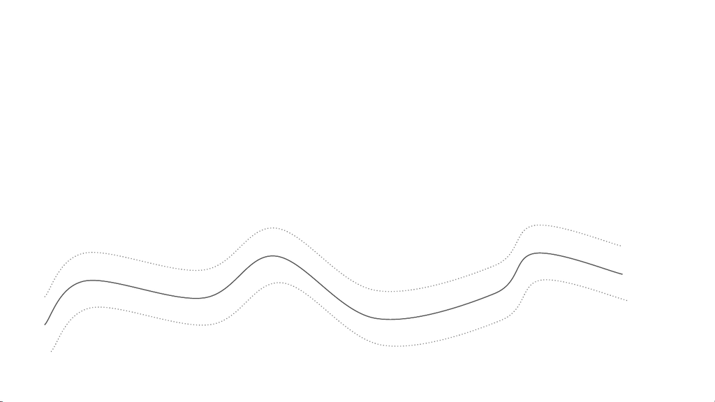

Univariate time series

A univariate time series {X(t)} is said to be second order or covariance stationary if the first two

moments, i.e., the mean E(X(t)) and covariance COV(X(t)), are invariant as a function of time

In other words, the first two moments of covariance-stationary time series are invariant over time

…

[figure not shown]

Multivariate time series

Multivariate time series are commonly modeled as vector auto-regressive (VAR) process

A VAR process is essentially a multivariate extension of an auto-regressive process

…

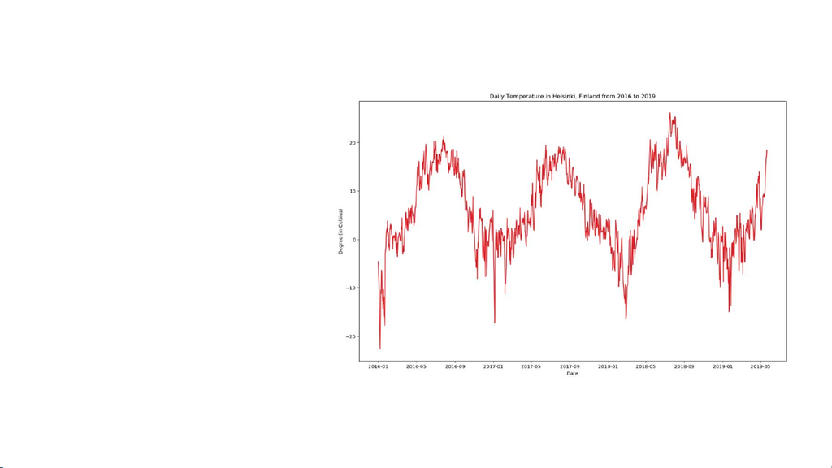

Lag orders

select suitable lag order via …

- AIC

- BIC

Assumptions in VAR

- multivariate normality

- normality of residuals

- absence of autocorrelation (???)

- heteroscedasticity

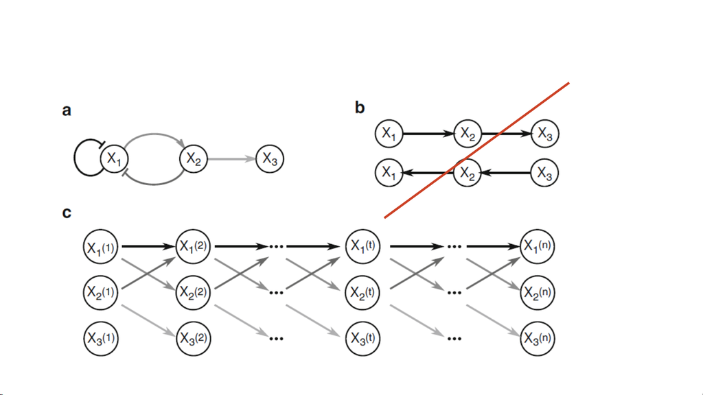

Dynamic Bayesian networks

Homogenous dynamic Bayesian networks

- the stochastic process is first-order Markovian

- values at time t of a variable are only dependant on the variables at t -1 (and not t -2, t -3, etc)

- Random values observed at time t are conditionally independent given the

random variables X(t −1) at the previous time t −1

- all information for a variable at a particular time point is in the immediate past

- The temporal profile of any variable Xi cannot be written as a linear combination

of the other profiles

- there are no edges going from one node to another in the same time bin

- The process is homogeneous over time: all arcs in the network and their

directions are invariant over time

- the phenomenon we are modeling is governed by the same set of rules during the whole

experiment

Learning algorithms

- repeated time measurements can be used to perform

linear regression

- only when n >> k

- regularized estimators required in most real world

applications

- LASSO (Least Absolute Shrinkage and Selection Operator)

- James–Stein Shrinkage

- First-Order Conditional Dependencies Approximation

- Modular Networks (SIMoNE)

Non-homogeneous dynamic Bayesian networks

- Homogeneity (Assumption 4 on slide 8) is a strong assumption

which may not be satisfied for real-world data

- ARTIVA (Auto-Regressive TIme VArying) model

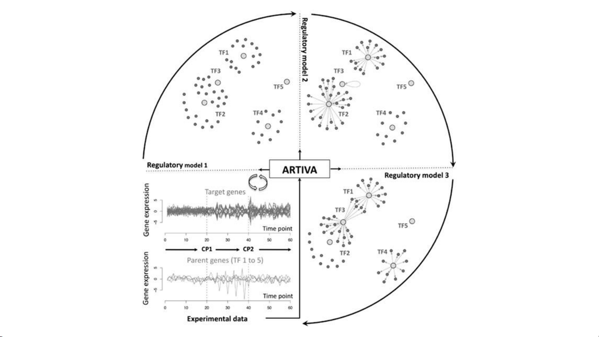

Analysis in R

homogenous (non-time varying effects)

- if n >> k

- package::var

- else shrinkage methods

-LASSO

- package::lars

- package::simone (specifically targeted to Bayesian networks)

- other shrinkage methods

- package::GeneNet

- package::G1DBN

non-homogenous (time varying effects)

- package::ARTIVA